# Survival Theory Course

Asymptotic analysis not using counting processes

Michael Sachs

# The process point of view revisited

# What is a process?

A stochastic *process* is a collection of random variables with an *index*.

An *empirical process* is a process computed from data.

Example, consider our random sample $X_1, \ldots, X_n$ from distribution $F$. The empirical cdf is
$$\mathbb{F}_n(t) = \frac{1}{n}\sum_{i = 1}^n I\{X_i \leq t\}.$$
This is a *random function* or *sample path*. We can view it as the collection of random variables $\{\mathbb{F}_n(t): t \in \mathbb{R}\}$.

Our statistic $T(X_1, \ldots, X_n)$ is now is a mapping from $\mathbb{R}^n$ to the *space of bounded increasing functions*.

# Analysis

How can we analyze the behavior of $\mathbb{F}_n(t)$?

For each fixed $t \in \mathbb{R}$ the laws of large numbers tells us that

$\mathbb{F}_n(t) \rightarrow_p F(t)$,

and the central limit theorem tells us that

$\sqrt{n}(\mathbb{F}_n(t) - F(t)) \rightarrow_d N(0, F(t)(1 - F(t)))$.

For $T_k = \{t_1, \ldots t_k\}$ a finite collection of $t$s the random vector of ecdfs evaluated at $T_k$ converges in distribution to a mean zero Gaussian vector with covariance $F(s \wedge t) - F(s) F(t)$ for $s, t \in T_k$, where $s \wedge t = \min\{s, t\}$.

Thinking about the random function, what other modes of convergence can we consider?

# Uniform convergence

Glivenko-Cantelli in 1933, proved something like

$$\sup_t|\mathbb{F}_n(t) - F(t)| \rightarrow_{as} 0,$$
as $n \rightarrow \infty$. This is called *uniform convergence* of the sample paths.

This is also written as

$$\| \mathbb{F}_n - F \|_\infty \rightarrow_{as} 0,$$
and this highlights the fact that the process point of view uses different notions of distance, since we are now in a *functional space* rather than Euclidean space. We will see later that this requires different notions of differentiability.

# Proof sketch

For any $\varepsilon > 0$, there exists a partition $-\infty = t_0, t_1, \ldots, t_m = \infty$ such that $F(t_j) - F(t_{j-1}) < \varepsilon$ for all $j$. Then noting that

$\mathbb{F}_n(t) - F(t) \leq \mathbb{F}_n(t_j) - F(t_{j-1})$ $= \mathbb{F}_n(t_j) - F(t_{j-1}) + F(t_j) - F(t_j) = \mathbb{F}_n(t_j) - F(t_{j}) + \varepsilon$.

and

$\mathbb{F}_n(t) - F(t) \geq \mathbb{F}_n(t_j) - F(t_{j}) - \varepsilon$, we have
$$\|\mathbb{F}_n - F \|_\infty \leq \max_{j}|\mathbb{F}_n(t_j) - F(t_j)| + \varepsilon.$$
The first term converges to 0 almost surely by the strong law of large numbers, and thus for any $m$, we can find an $N$ such that for all $n \geq N$,

$$\sup_{m\geq n}\| \mathbb{F}_m - F \|_\infty \leq \varepsilon.$$
Since $\varepsilon$ was arbitrary, the result follows.

# Some details

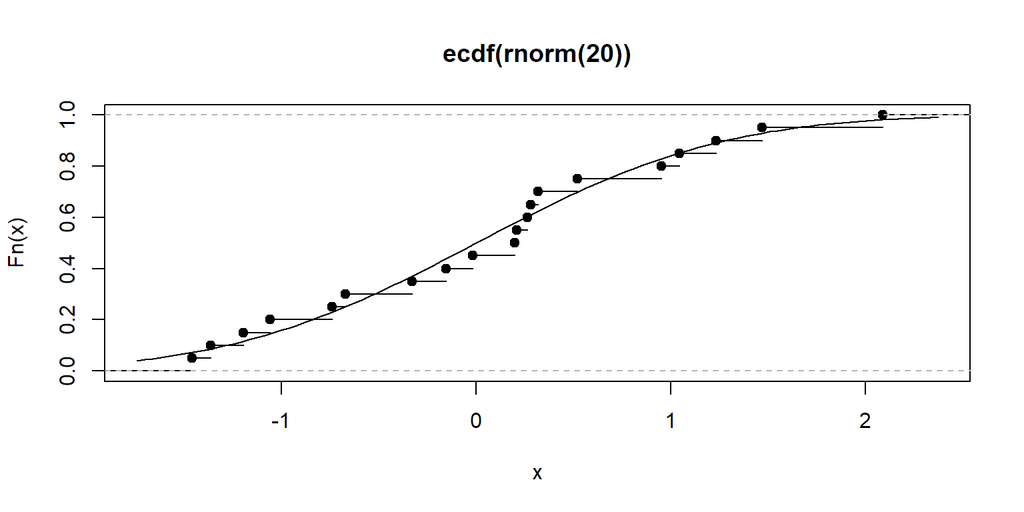

- For any $\varepsilon > 0$, we can find a partition of the range such that the largest jump size is still less than $\varepsilon$. In the case of semi-continuous distributions, jumps larger than that occur with probability 0 (it must be a finite set of discontinuities)
- Use that partition to convert the problem to the finite dimension, and use the classical results combined with some calculus.

# Convergence in distribution

Given the classical finite dimensional result, we might surmise that $\sqrt{n}(\mathbb{F}_n - F)$ converges to some sort of Gaussian process with mean 0 and covariance $F(s \wedge t) - F(t)F(s)$.

Donsker proved just that in 1952, and made more general/rigorous by Skorokod and Kolmogorov in 1956.

Specifically, $\sqrt{n}(\mathbb{F}_n - F) \Rightarrow G$ in the space of upper semi-continuous functions $D[-\infty, \infty]$ on $\mathbb{R}$ equipped with the uniform norm $\|_\infty$, where $G$ is an element of that space that satisfies $E(G(t)) = 0$ and $Cov(G(t)G(s))$ as above, for every $t, s \in \mathbb{R}$.

To be complete, we would also specify that $G$ is *tight*, meaning that for every $\varepsilon > 0$, there exists a closed and bounded set $K \subset D[-\infty, \infty]$ such that $P(G \notin K) < \varepsilon$. This is a fancy way of saying that the sample paths of $G$ do not explode to infinity, and it holds because the mean and variance functions are bounded.

# The Portmanteau lemma

This theorem establishes some intuition about convergence in distribution of random functions.

*The following are equivalent*:

1. $X_n \Rightarrow X$.
2. $P(X_n < x) \rightarrow P(X < x)$ for all continuity points of $x \mapsto P(X < x)$
3. $E(f(X_n)) \rightarrow E(f(X))$ for all bounded continuous functions $f$

This automatically establishes a sort of continuous mapping theorem. The key difference here is that the functions $f$ map from the space of functions equipped with $\|_\infty$ to some other space (usually $\mathbb{R}$), this opens up a lot of possibilities!

Exercise: consider the function $g(F) = \sup_{t \in \mathbb{R}} |F(t)|$. Is it continuous? How would you use this plus the continuous mapping theorem to construct confidence bands for the empirical CDF?

# General empirical measures

Donsker actually proved these things in much more generality. Consider the empirical distribution function:
$$\frac{1}{n}\sum_{i = 1}^n I\{X_i \leq t\},$$
which we viewed as a process with index defined by $t$. Instead, view the indicator function itself as an instance of the index, i.e., the general empirical process is
$$\mathbb{P}_n f = \frac{1}{n}\sum_{i = 1}^n f(X_i),$$
for an arbitrary function $f$ from the sample space to $\mathbb{R}$. Then
$$\{\mathbb{P}_n f, f \in \mathcal{F} \}$$
is a process indexed by $f$ for some class of functions $\mathcal{F}$. Studying the behavior of classes of functions leads to results about the asymptotic behavior of the processes. For example $\mathcal{F} = \{f(x) = I(x \leq t), t \in \mathbb{R}\}$.

# The functional delta method

We have now established $\sqrt{n}(\mathbb{F}_n - F) \Rightarrow G$ in the space $D[-\infty, \infty]$. There are many statistics that can be written in terms of “functionals” $\phi: D[-\infty, \infty] \rightarrow \mathbb{R}$. For example,

- The mean: $\phi(F) = \int x \, dF$
- Quantiles: $\phi(F) = F^{-1}(p)$ such that $F F^{-1}(p) = p$
- Wilcoxon statistic (two-sample): $\phi(F, G) = \int F\, dG$
- Z-estimators: $\phi$ is the mapping from the cdf to a zero of an estimating function
- M-estimators: mapping to the maximum of a function
- …

To analyze the asymptotic behavior of such statistics, we might think that there is some version of the delta method that tells us
$$\sqrt{n}(\phi(\mathbb{F}_n) - \phi(F)) \Rightarrow \phi'(G),$$
where $\phi'$ is a derivative, in some sense.

# Notions of differentiability

We are not going to cover the technical details, but remember that we are operating in the space $D[-\infty, \infty]$ equipped with the supremum norm. Compared to standard Euclidean space, where derivatives are in terms of
$$\frac{f(x + dx) - f(x)}{dx},$$
this opens up a lot of possibilities regarding the direction of approaching the function. $dx$ in the above now needs to be a small change in a function.

1. Gateaux – Look at all fixed functions $h$: $lim_{t \rightarrow 0} \phi(F + t h) - \phi(F)$
2. Hadamard – Look at sequences of functions $h_t$ as $h_t \rightarrow h$
3. Fréchet – Look at $\phi(F + h)$ as $\|h\| \rightarrow 0$.

Hadamard is the sweet spot, and we have the functional delta method:
$$\sqrt{n}(\phi(\mathbb{F}_n) - \phi(F)) \Rightarrow \phi'(G),$$
where $\phi'$ is the Hadamard derivative of $\phi$.

# Taylor expansion

Specifically,

$$\phi(\mathbb{F}_n) - \phi(F) = \frac{1}{\sqrt{n}}\phi'(\mathbb{F}_n - F) + o(\frac{1}{\sqrt{n}}) =$$
$$\frac{1}{n}\sum_{i= 1}^n\phi'(\delta_{X_i} - F) + o(\frac{1}{\sqrt{n}}),$$
where $\delta_i$ is the discrete distribution with point mass at $X_i$. $x \mapsto \phi'(\delta_x - F)$ is the *influence function* of $\phi$. This is the thing you want to calculate to derive asymptotic distributions:

$$\phi'(\delta_x - F) = \left. \frac{d}{dt} \phi((1 - t) F + t \delta_x) \right|_{t=0}.$$

# Some basic derivatives

- Integral: for $\phi(F) = \int s \, dF(s)$, $\phi'(\delta_x - F) = x - \int s \, dF(s)$
- Inverse: for $\phi(F) = F^{-1}(p)$,
  $$\phi'(\delta_x - F) = \frac{-I(F^{-1}(p) \geq x) - p}{f(F^{-1}(p))}.$$
- Composition/chain rule: if $\phi$ and $\psi$ are Hadamard differentiable, then so is $\psi \circ \phi$ and it has derivative $\psi' \circ \phi'$.

# Applications

The previous results can be used to derive the asymptotic distributions of these statistics.

- ROC curve (Hsieh and Turnbull 1996)
- Predictiveness curve (Sachs and Zhou 2013)
- Nelson-Aalen estimator (Gill 1989, Example 3)
- Kaplan-Meier estimator (Breslow and Crowley 1974)

# Nelson-Aalen estimator

From Van der Vaart (1998), Example 20.15:

We wish to estimate the cumulative hazard function $A$ of a random sample of failure times $T_1, \ldots, T_n$ from distribution $F$. But, we only observe $(X_i, \Delta_i)$ where $X_i = T_i \wedge C_i$, and $\Delta_i = I(T_i \leq C_i)$. Assume that $C_1, \ldots, C_n$ are a random sample from distribution $G$.

Note that $P(X_i > x) = (1 - F(x))(1 - G(x)) = 1 - H(x)$ and $P(X_i \leq x, \Delta_i = 1) = (1 - G(x-))\,dF(x) = H_1(x)$. We can write

$$A(t) = \int_0^t \frac{1}{1 - F(s-)}\, dF(s) = \int_0^t \frac{1}{1 - H(s-)}\, dH_1(s).$$
Further, we can estimate $H$ and $H_1$ by their empirical counterparts: $\hat{H}(x) = n^{-1}\sum_{i = 1}^nI(X_i \leq x)$ and $\hat{H}_{1}(x) = n^{-1}\sum_{i = 1}^n I(X_i \leq x, \Delta_i = 1)$. Plugging these into the above yields the Nelson-Aalen estimator
$$\hat{A}(t) = \int_0^t \frac{1}{1 - \hat{H}(s-)}\, d\hat{H}_1(s).$$

# Asymptotic properties

Because they are empirical cdfs, the pair $(\hat{H}, \hat{H}_1)$ converges to a bivariate Gaussian process in the space $D\times D$.

The Nelson-Aalen estimator can be viewed as a series of maps:
$$(A, B) \mapsto (1 - A, B) \mapsto (\frac{1}{1 - A}, B) \mapsto \int_0^t\frac{1}{1 - A_-}\, dB.$$

Each of these are Hadamard differentiable and hence so is their composition, as long as $H(t) < 1$.

It follows that the Nelson-Aalen estimator converges to a Gaussian process in $D[0, \tau]$ for every $\tau$ such that $H(\tau) < 1$.

# Kaplan-Meier

In ABGK, they note that the product integral is Hadamard differentiable (as a mapping from $D[0,t]$ to itself, i.e., a function of $A$) and with
$$S(t) = \prod_u^t\{1 - dA(u)\}$$
the derivative is (for $h \in D[0, t]$)
$$(dS(A)\cdot h)(s) = -\int_0^sS(u-)\frac{S(s)}{S(u)}\, dh(u) = -S(s)h(s).$$
Hence plugging in $\hat{A}$ for $h$ in the above, we have another proof that
$$\sqrt{n}(\hat{S}(\cdot) - S(\cdot)) \Rightarrow -S(\cdot) W(\sigma(\cdot)),$$
this time using the functional delta method.

# The Breslow and Crowley approach

From the life-table approach, we partition the range $[0, t]$ into a series of $K$ intervals with $\xi_0 < \xi_1 < \cdots < \xi_K < t$. For each interval, we can compute the conditional probability of death within that interval given survival up to the start of the interval as
$$q_k = (F(\xi_k) - F(\xi_{k - 1})) / (1 - F(\xi_{k - 1})).$$
The unconditional survival beyond $\xi_k$ is computed as $P_k = (1 - q_1)\cdots(1 - q_k)$.

The vector $\hat{q} = (\hat{q}_1, \ldots, \hat{q}_K)$, with the proportions estimated in the obvious way, is asymptotically multivariate normal.

The vector of survival probabilities $(P_1, \ldots, P_K)$ is a smooth mapping of the conditional probabilities hence we can apply the delta method.

Breslow and Crowley then take the limit as $K \rightarrow \infty$ in order to derive the limiting process of the Kaplan-Meier estimator (similar to the proof of the Glivenko-Cantelli theorem).

Gill and others viewed this approach as overly technical and inelegant, so they went on to develop the approach using counting processes and martingales.

# Summary

- In the process point of view, we still have some standard results like the delta method, continuous mapping theorem, etc.
- Complications arise due to the functional space compared to the Euclidean space.
- Nevertheless, these tools exist and can be applied in different scenarios
- Remember it is not one or the other, both approaches have their merits and complementary uses.